# Tarea 4 Genómica Funcional 2025

Julieta González

12 abril, 2025

# Tarea 4

## (20 %) Preguntas rápidas (simples)

1. Considera una red de 15 nodos . Considera que tienes una sola conexión. ¿Cuál es el número máximo de nodos que puedes conectar? Dado un solo nodo , ¿cuál es el número máximo conexiones que puede tener tal nodo?

Puesto que sólo hay una conexión, esta entonces une a dos nodos, por lo que el número máximo de nodos que se pueden conectar es 2 (A->B). El número máximo de conexiones que puede tener un nodo no puede ser mayor al número de nodos total, por lo que el número máximo que puede tener un nodo en este caso es de 15-1 = 14; 14 nodos.

2. Considera una red dirigida de 10 nodos. Usa 25 conexiones y dibuja una red con ese número de nodos y conexiones dirigidas. Calcula la distribución de conectividades de salida.Calcula el número total de conexiones de salida ¿Cómo se compara el número total de de conectividades de entrada (son iguales, diferentes)? Explica tu respuesta. Calcula el promedio de entrada y de salida. Discute tu resultado.

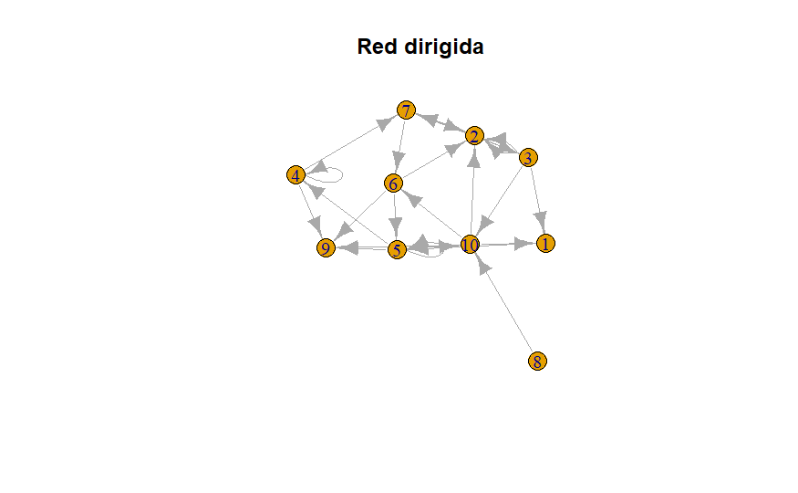

Para los promedios de grado de salida y entrada se obtuvo un valor de 2.5. Esto sucede porque al tener 25 conexiones, el número total del grado es 25. Entonces hay 25 conexiones “salientes” (out) y 25 “entrantes” (in), y como hay 10 nodos, lo que se hace para calcular la media es 25/10, que es igual a 2.5. Aunque en primeria instancia se podría pensar que los loops hacia su mismo nodo afectan el degree de entrada y salida de un nodo, en este caso el promedio se mantuvo estable incluso con la presencia de estos. Los self-loops pueden afectar el grado del nodo de origen al agregarle +1 para el grado in y out, y dependiendo del contexto, estos deben o no ser removidos, como en el caso de la red de amigos, donde se tuvieron que remover los self-loops generados por aquellos que se eligieron como su propio amigo.

3. Considera una red no dirigida de $n=3,4,5,6$ nodos respectivamente. ¿Cuál es el número máximo de conexiones que puedes poner? Dibuja cada caso. ¿Qué pasa si la red es dirigida?

El número máximo de conexiones que se puede poner sin que un nodo se diriga a sí mismo es calculado mediante k(k-1)/2.